# Section 7: Discriminant Analysis

Pablo Arés Gastesi

2026-07-07

# 1 Introduction

We have already studied logistic regression as a classification method. Logistic regression is easy to interpret: the coefficients tell us directly how each predictor influences the log-odds of belonging to a class. However, it becomes cumbersome when the response has more than two classes, and it can be unstable when the classes are well-separated or the predictors are close to normally distributed.

**Discriminant analysis** is an alternative that handles multiple classes naturally and rests on a solid probabilistic foundation. We will study two versions: **Linear Discriminant Analysis (LDA)**, which assumes all classes share the same covariance structure, and **Quadratic Discriminant Analysis (QDA)**, which allows each class its own covariance.

# 2 The Bayes Framework

In logistic regression we model $P(Y = k \mid X = x)$ directly. In discriminant analysis we take the opposite route: we model the distribution of $X$ within each class and then use **Bayes’ theorem** to turn it around.

Bayes’ theorem states:

$$P(Y = k \mid X = x) = \frac{P(X = x \mid Y = k)\, P(Y = k)}{P(X = x)}$$

The three ingredients are:

- **Prior** $P(Y = k)$: the overall proportion of class $k$ in the training data. Easy to estimate.
- **Likelihood** $P(X = x \mid Y = k)$: the probability of observing the data $x$ if the observation truly belongs to class $k$. This is what we model.
- **Evidence** $P(X = x)$: the marginal probability of the data. Hard to compute, but since it is the same for all classes it can be ignored when comparing classes.

So in practice we assign an observation to the class $k$ that maximises:

$$\text{posterior} \propto \text{likelihood} \times \text{prior}$$

To compute the likelihood we assume that, within each class, $X$ follows a multivariate normal distribution. LDA additionally assumes that all classes share the same covariance matrix $\Sigma$; QDA allows a separate $\Sigma_k$ per class.

# 3 The Two-Class Case

## 3.1 Geometric intuition

The easiest setting to visualise is two classes in two dimensions. We look for a **line** (or more generally a hyperplane) that best separates the classes — meaning the projections of the two groups onto this line are as far apart as possible, while the spread within each group is as small as possible.

Formally, if $\bar{x}_1$ and $\bar{x}_2$ are the class centroids and $s_1^2, s_2^2$ are the within-class variances along the projection direction, we maximise **Fisher’s criterion**:

$$\frac{(\bar{x}_1 - \bar{x}_2)^2}{s_1^2 + s_2^2}$$

Let us illustrate with a small dataset of 10 points, five in each class.

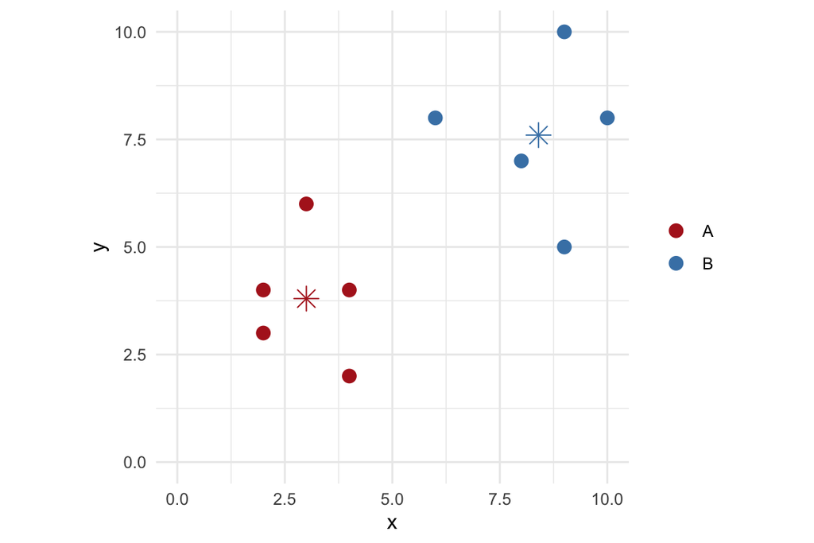

Figure 3.1: Two clearly separated classes with their centroids (stars)

```r
toy <- data.frame(
  x     = c(4, 2, 2, 3, 4, 9, 6, 9, 8, 10),
  y     = c(2, 4, 3, 6, 4, 10, 8, 5, 7, 8),
  label = factor(rep(c("A", "B"), each = 5))
)

centroids <- toy %>%
  group_by(label) %>%
  summarise(x = mean(x), y = mean(y))

ggplot(toy, aes(x = x, y = y, colour = label)) +
  geom_point(size = 3) +
  geom_point(data = centroids, aes(x = x, y = y),
             shape = 8, size = 4, show.legend = FALSE) +
  scale_colour_manual(values = c(A = "firebrick", B = "steelblue")) +
  coord_fixed() +
  expand_limits(x = 0, y = 0) +
  labs(colour = NULL) +
  theme_minimal()
```

The centroids are at $\bar{x}_A = (3, 3.8)$ and $\bar{x}_B = (8.4, 7.6)$. The prior probabilities are both 0.5 since the classes are equally sized.

## 3.2 Finding the discriminant direction

We project all points onto the line that maximises Fisher’s criterion. Finding this direction involves eigenvectors of the within-class scatter matrix — the computation is handled by the software. Once we have it, each point is projected onto the line and the class boundary is set at the midpoint between the two projected centroids (when priors are equal).

```r
lda_toy <- lda(label ~ x + y, data = toy)
lda_toy
```

```
## Call:
## lda(label ~ x + y, data = toy)
##
## Prior probabilities of groups:
##   A   B
## 0.5 0.5
##
## Group means:
##     x   y
## A 3.0 3.8
## B 8.4 7.6
##
## Coefficients of linear discriminants:
##         LD1
## x 0.6913849
## y 0.3174452
```

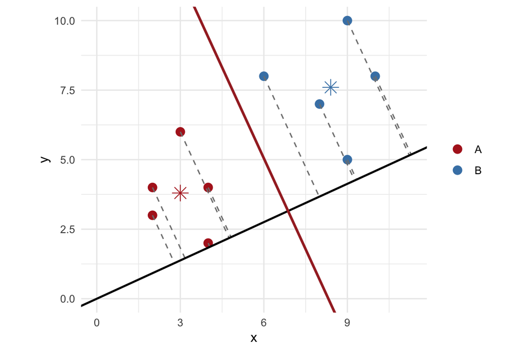

Figure 3.2: Optimal projection direction (solid line) with perpendicular class boundary (brown). Dashed lines show each point’s projection.

```r
# projection function onto LD1
slope_ld <- lda_toy$scaling[2] / lda_toy$scaling[1]
proj <- function(px, py) {
  t <- (lda_toy$scaling[1] * px + lda_toy$scaling[2] * py) /
       sum(lda_toy$scaling^2)
  list(xend = lda_toy$scaling[1] * t,
       yend = lda_toy$scaling[2] * t)
}
p <- proj(toy$x, toy$y)
toy_proj <- toy %>% mutate(xend = p$xend, yend = p$yend)

# boundary: perpendicular to LD1 through midpoint of projected centroids
mid_x <- mean(centroids$x)
mid_y <- mean(centroids$y)
slope_boundary <- -1 / slope_ld
intercept_boundary <- mid_y - slope_boundary * mid_x

ggplot(toy_proj, aes(x = x, y = y, colour = label)) +
  geom_point(size = 3) +
  geom_point(data = centroids, aes(x = x, y = y),
             shape = 8, size = 4, show.legend = FALSE) +
  geom_segment(aes(xend = xend, yend = yend),
               linetype = "dashed", colour = "grey50") +
  geom_abline(slope = slope_ld, intercept = 0,
              colour = "black", linewidth = 0.8) +
  geom_abline(slope = slope_boundary, intercept = intercept_boundary,
              colour = "brown", linewidth = 1) +
  scale_colour_manual(values = c(A = "firebrick", B = "steelblue")) +
  coord_fixed() +
  expand_limits(x = 0, y = 0) +
  labs(colour = NULL) +
  theme_minimal()
```

## 3.3 Verifying predictions by hand

The **discriminant function** reported by `lda` is:

$$\text{LD1} = a_1 (x - \bar x) + a_2 (y - \bar y)$$

where $a_1, a_2$ are the coefficients in `lda_toy$scaling` and $\bar x, \bar y$ are the grand means. Positive values of LD1 correspond to one class and negative values to the other. We can verify this manually:

```r
a1 <- lda_toy$scaling[1]
a2 <- lda_toy$scaling[2]
xbar <- mean(toy$x)
ybar <- mean(toy$y)

disc <- function(px, py) a1 * (px - xbar) + a2 * (py - ybar)

test_pts <- data.frame(x = c(9, 3), y = c(2, 0),
                       expected = c("B", "A"))
test_pts$LD1_manual  <- disc(test_pts$x, test_pts$y)
test_pts$LD1_predict <- predict(lda_toy, newdata = test_pts[, c("x","y")])$x[, 1]
test_pts$class       <- predict(lda_toy, newdata = test_pts[, c("x","y")])$class
test_pts
```

| x | y | expected | LD1_manual | LD1_predict | class |
| --- | --- | --- | --- | --- | --- |
| 9 | 2 | B | 1.107023 | 1.107023 | B |
| 3 | 0 | A | -3.676177 | -3.676177 | A |

The manual and predicted values match exactly, confirming the formula.

# 4 The Admissions Dataset

## 4.1 Fitting LDA

We now apply LDA to the admissions data, using both GPA and GMAT as predictors and the three-class response (`admit`, `border`, `notadmit`).

```r
admission <- read_csv("admission.csv", show_col_types = FALSE)
colnames(admission)[3] <- "decision"
admission$decision <- factor(admission$decision,
                             levels = c("notadmit", "border", "admit"))
```

```r
lda_fit  <- lda(decision ~ GPA + GMAT, data = admission)
lda_fit
```

```
## Call:
## lda(decision ~ GPA + GMAT, data = admission)
##
## Prior probabilities of groups:
##  notadmit    border     admit
## 0.3294118 0.3058824 0.3647059
##
## Group means:
##               GPA     GMAT
## notadmit 2.482500 447.0714
## border   2.992692 446.2308
## admit    3.403871 561.2258
##
## Coefficients of linear discriminants:
##              LD1         LD2
## GPA  5.008766354 -1.87668220
## GMAT 0.008568593  0.01445106
##
## Proportion of trace:
##    LD1    LD2
## 0.9673 0.0327
```

The output shows the **prior probabilities** (proportion of each class in the data), the **group means** (centroids), and the **coefficients of the linear discriminants**. With three classes, LDA produces $K - 1 = 2$ discriminant functions (LD1 and LD2).

## 4.2 Class centroids and data

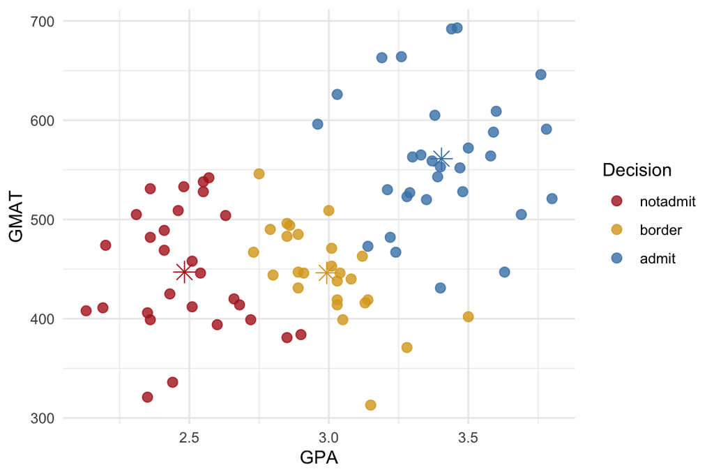

Figure 4.1: GPA vs GMAT coloured by decision, with class centroids (stars)

```r
cents <- admission %>%
  group_by(decision) %>%
  summarise(GPA = mean(GPA), GMAT = mean(GMAT))

ggplot(admission, aes(x = GPA, y = GMAT, colour = decision)) +
  geom_point(size = 2.5, alpha = 0.8) +
  geom_point(data = cents, aes(x = GPA, y = GMAT),
             shape = 8, size = 4, show.legend = FALSE) +
  scale_colour_manual(values = c(notadmit = "firebrick",
                                 border   = "goldenrod",
                                 admit    = "steelblue")) +
  labs(colour = "Decision") +
  theme_minimal()
```

## 4.3 Decision regions

The `partimat` function from `klaR` draws the LDA decision regions — the areas of the predictor space assigned to each class — together with the training points.

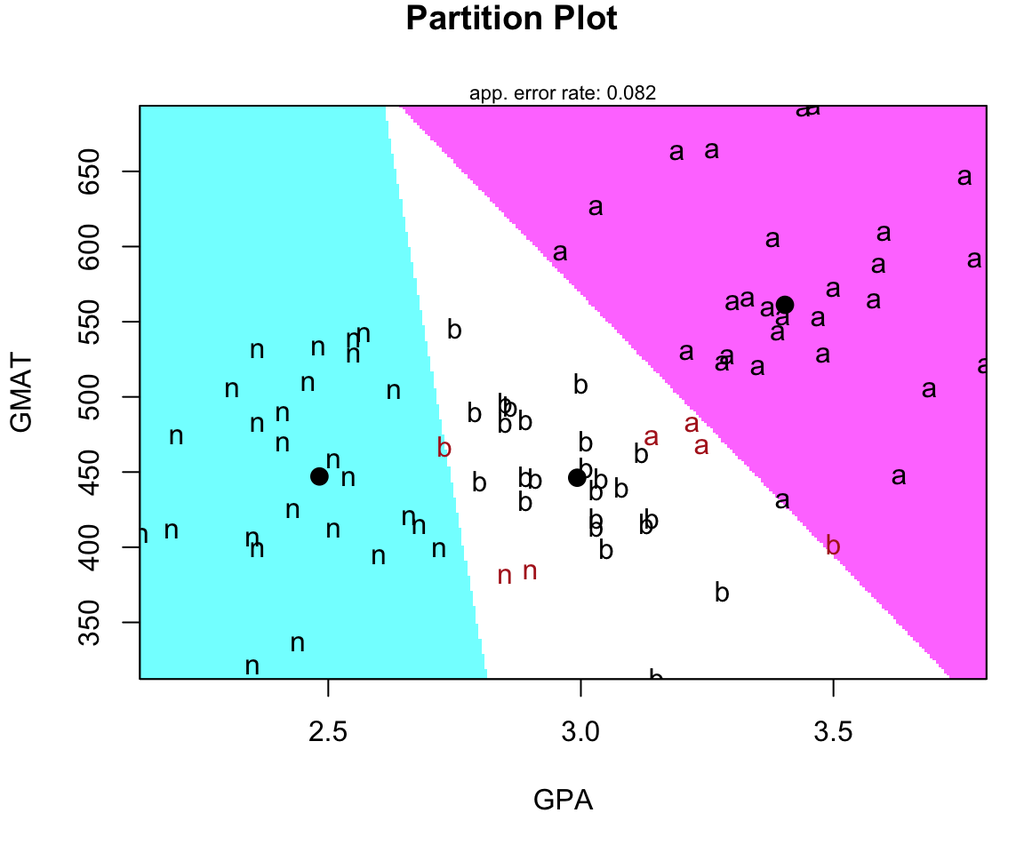

Figure 4.2: LDA decision regions for the admissions data

```r
partimat(decision ~ GMAT + GPA, data = admission,
         method = "lda", prec = 300,
         col.correct = "black", col.wrong = "firebrick")
```

## 4.4 Confusion matrix

```r
lda_pred <- predict(lda_fit, newdata = admission)
cm_lda   <- table(Real = admission$decision,
                  Predicted = lda_pred$class)
cm_lda
```

```
##           Predicted
## Real       notadmit border admit
##   notadmit       26      2     0
##   border          1     24     1
##   admit           0      3    28
```

```r
cat("\nOverall accuracy:", round(sum(diag(cm_lda)) / sum(cm_lda), 4), "\n")
```

```
##
## Overall accuracy: 0.9176
```

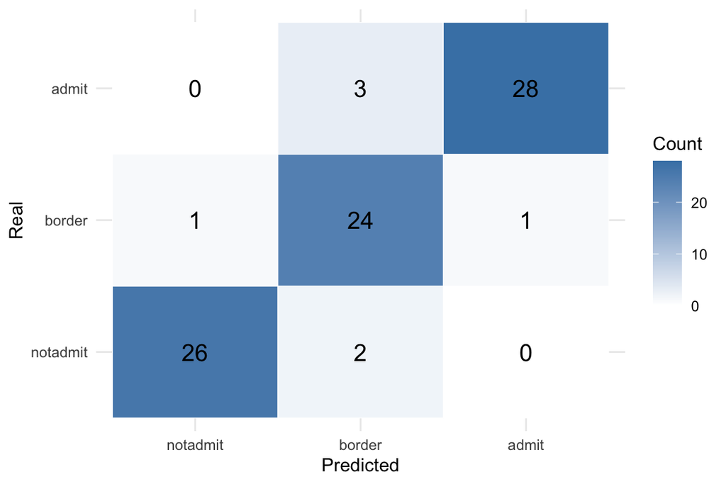

Figure 4.3: Confusion matrix for the LDA model

```r
as.data.frame(cm_lda) %>%
  ggplot(aes(x = Predicted, y = Real, fill = Freq)) +
  geom_tile(colour = "white") +
  geom_text(aes(label = Freq), size = 5) +
  scale_fill_gradient(low = "white", high = "steelblue") +
  labs(fill = "Count") +
  theme_minimal()
```

## 4.5 Discriminant score distributions

With three classes and two discriminant functions, we can visualise how well LD1 and LD2 separate the groups using `ldahist`.

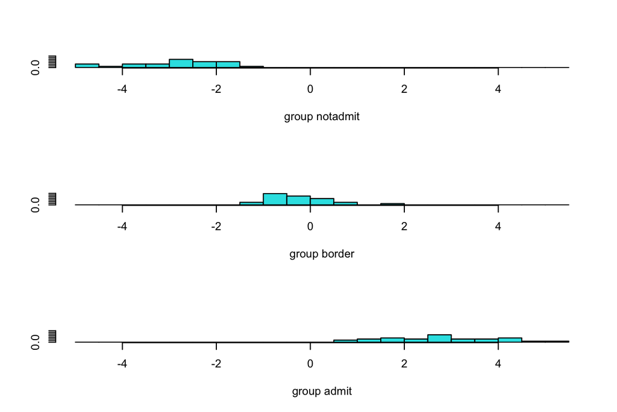

Figure 4.4: Distribution of LD1 scores by class

```r
ldahist(data = lda_pred$x[, 1], g = admission$decision)
```

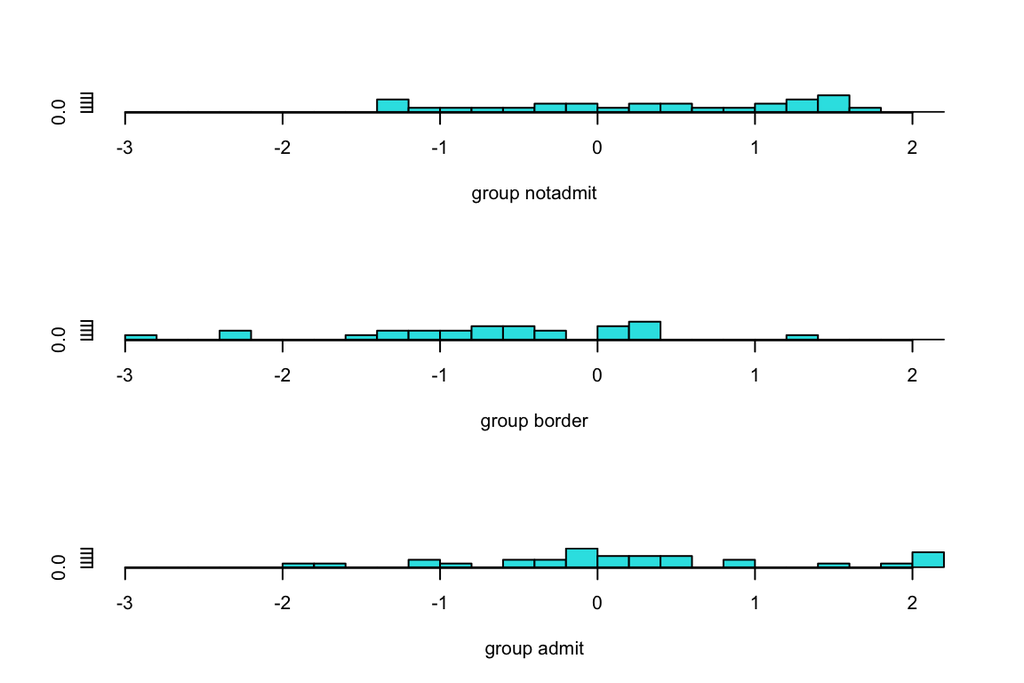

Figure 4.5: Distribution of LD2 scores by class

```r
ldahist(data = lda_pred$x[, 2], g = admission$decision)
```

We can also look at the two discriminant functions simultaneously:

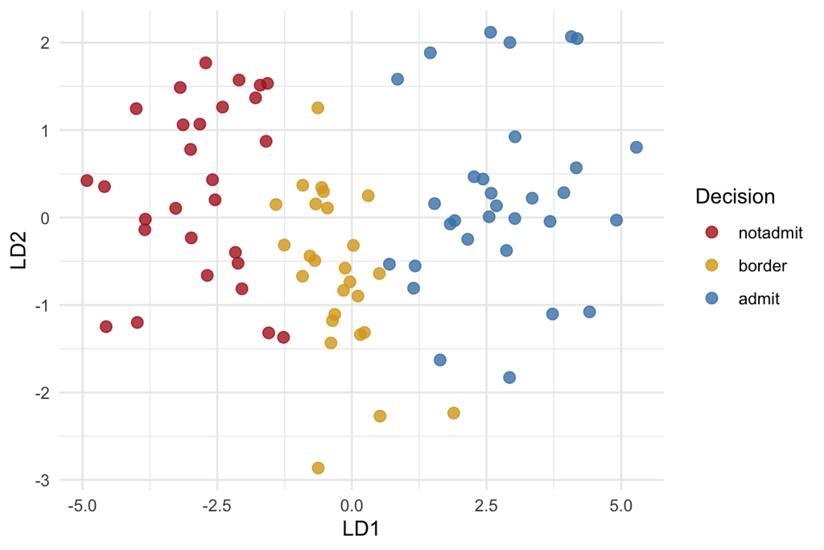

Figure 4.6: Observations in the LD1–LD2 space

```r
ld_df <- as.data.frame(lda_pred$x) %>%
  mutate(decision = admission$decision)

ggplot(ld_df, aes(x = LD1, y = LD2, colour = decision)) +
  geom_point(size = 2.5, alpha = 0.8) +
  scale_colour_manual(values = c(notadmit = "firebrick",
                                 border   = "goldenrod",
                                 admit    = "steelblue")) +
  labs(colour = "Decision") +
  theme_minimal()
```

# 5 Quadratic Discriminant Analysis

## 5.1 When to use QDA

LDA works well when the classes have **similar covariance matrices**. When this assumption is violated — when the spread and orientation of the classes differ substantially — the linear decision boundary is the wrong shape, and **QDA** should be preferred.

QDA fits a separate covariance matrix $\Sigma_k$ for each class. The decision boundary between two classes is then a quadratic curve (a conic section) rather than a straight line. The trade-off is that QDA has more parameters and needs more data to estimate them reliably.

|  | LDA | QDA |
| --- | --- | --- |
| Covariance | Shared $\Sigma$ | Per-class $\Sigma_k$ |
| Boundary | Linear | Quadratic |
| Parameters | Fewer | More |
| Best when | Covariances similar, $n$ small | Covariances differ, $n$ large |

## 5.2 Fitting QDA

In R, only the function name changes:

```r
qda_fit  <- qda(decision ~ GPA + GMAT, data = admission)
qda_pred <- predict(qda_fit, newdata = admission)

cm_qda <- table(Real = admission$decision,
                Predicted = qda_pred$class)
cm_qda
```

```
##           Predicted
## Real       notadmit border admit
##   notadmit       27      1     0
##   border          0     25     1
##   admit           0      1    30
```

```r
cat("\nOverall accuracy:", round(sum(diag(cm_qda)) / sum(cm_qda), 4), "\n")
```

```
##
## Overall accuracy: 0.9647
```

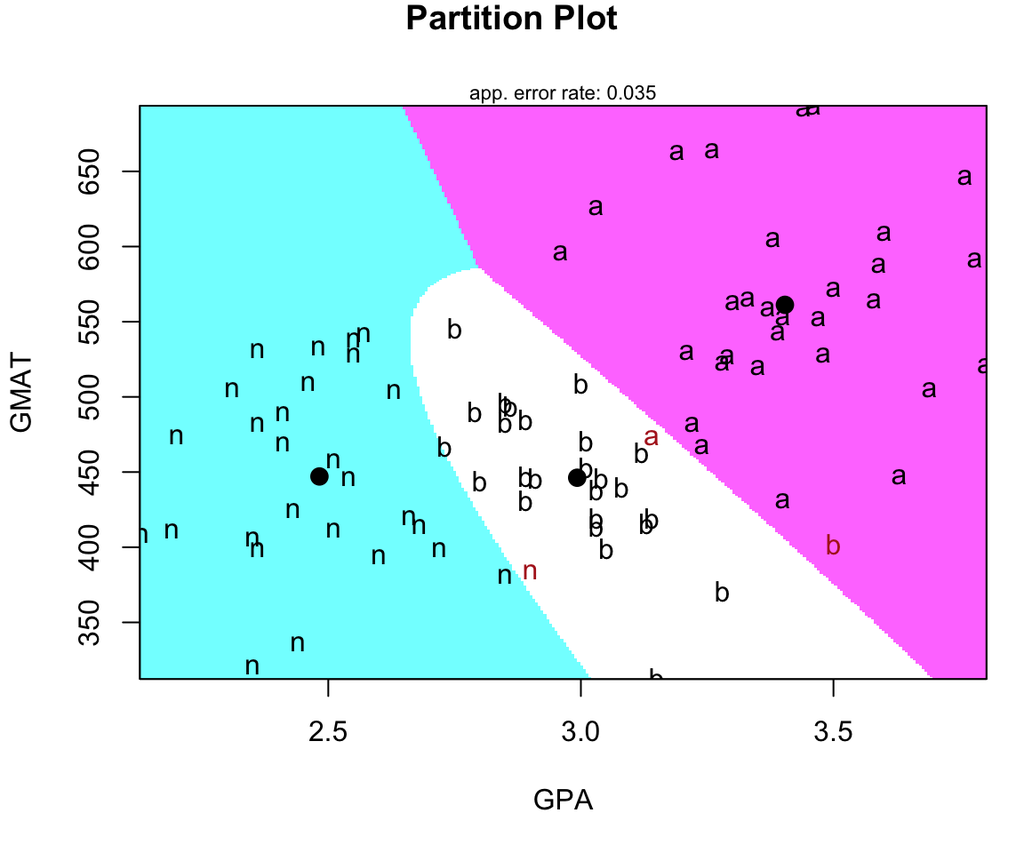

Figure 5.1: QDA decision regions for the admissions data

```r
partimat(decision ~ GMAT + GPA, data = admission,
         method = "qda", prec = 300,
         col.correct = "black", col.wrong = "firebrick")
```

# 6 Summary

| Method | Boundary | Covariance assumption | Fit in R |
| --- | --- | --- | --- |
| LDA | Linear | All classes share $\Sigma$ | `lda()` from `MASS` |
| QDA | Quadratic | Each class has its own $\Sigma_k$ | `qda()` from `MASS` |

Both methods are based on the same Bayes framework: assign each observation to the class with the highest posterior probability, estimated as $\text{likelihood} \times \text{prior}$. The likelihood is modelled with a multivariate normal distribution within each class.

LDA produces $K - 1$ discriminant functions that can be inspected with `ldahist` and plotted in the discriminant space. `partimat` from `klaR` visualises the decision regions directly in the predictor space.

The key practical message, which applies to all classification methods: **always evaluate on a test set or with cross-validation**, not on the training data used to fit the model.